# Diagnostics III

## Projects

## Proposals recap

- Many groups are `merge()`ing data, which is great. Make sure the rows align!
- Population, sample, and the observational unit.

## This week

- *Data cleaning*
- *Exploratory Data Analysis*: use the tools we started this class with (`mplot()`, `ggplot2`, `lattice`) to explore the structure in your data. Distribution of your variables (histograms, density plots), predictors vs response, relationships between predictors. Use scatterplots, boxplots, etc.
- *Work in Markdown!!!* be sure all your plots and data manipulation is completely transparent and reproducible.

## Activity 9

1. Fit the model \(price \sim sqft + bed + city\).
2. By the rules of thumb, are those two points high leverage? Outliers? (you can extract the hat values using `influence(m1)$hat`.)
3. Calculate the Cook's distance of those two observations using the equation: \(D_i = ((r_i^2)/(p + 1)) * ((h_{ii})/(1 - h_{ii}))\).
4. Generate the Cook's distance plot to double check that the values that you calculated in 3 seem correct.
5. Now fit the more appropriate model, with \(logprice\) and \(logsqrt\) and construct added variable plots. What do you learn about the relative usefulness of \(logsqft\) and \(bed\) as predictors?

## High leverage?

```r
LA <- read.csv("http://andrewpbray.github.io/data/LA.csv")
m1 <- lm(price ~ sqft + bed + city, data = LA)
levs <- influence(m1)$hat
```

## High leverage?

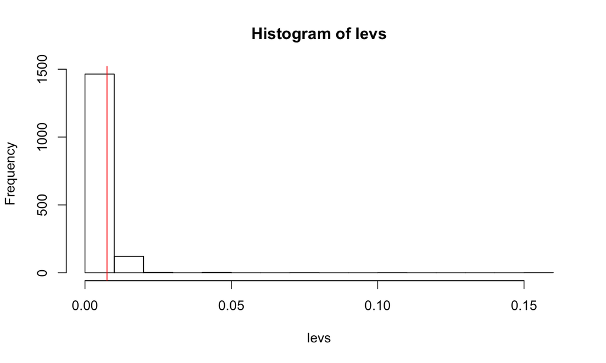

```
##    1255    1289    1277    1293    1294    1292
## 0.04203 0.04301 0.04827 0.07888 0.10424 0.15780
```

## High residual?

```r
e_hat <- m1$res
s <- sqrt(1/(nrow(LA) - length(m1$coef)) * sum(e_hat^2))
r <- e_hat/(s * sqrt(1 - levs))
head(r)
```

```
##       1       2       3       4       5       6
## -0.1251 -0.1450 -0.1156 -0.5685 -1.0501  0.2048
```

```r
head(rstandard(m1))
```

```
##       1       2       3       4       5       6
## -0.1251 -0.1450 -0.1156 -0.5685 -1.0501  0.2048
```

## High residual?

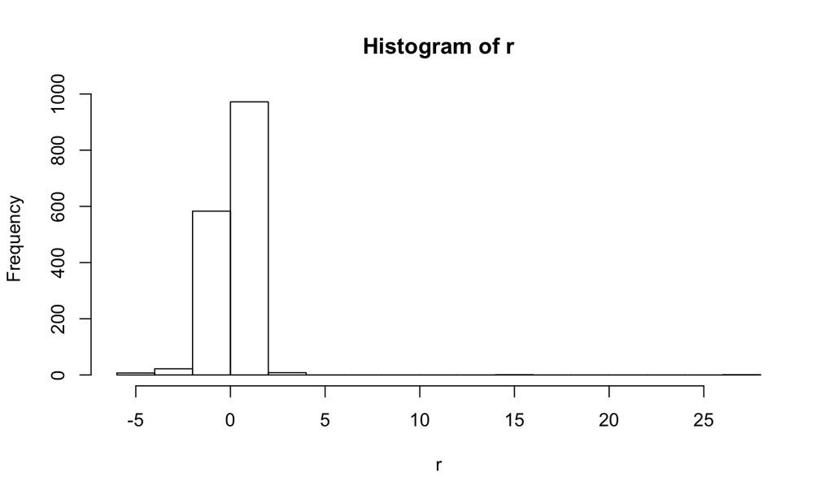

```r
hist(r)
```

```r
tail(sort(r))
```

```
##   1193   1287   1288   1096   1294   1292
##  3.579  3.664  3.664  3.745 14.660 27.696
```

## Influence

```r
cdist <- (r^2 / length(m1$coef)) * (levs/(1 - levs))
tail(sort(cdist))
```

```
##     1254     1260     1291     1289     1294     1292
##  0.05409  0.05848  0.08015  0.09034  4.16812 23.95309
```

## Influence

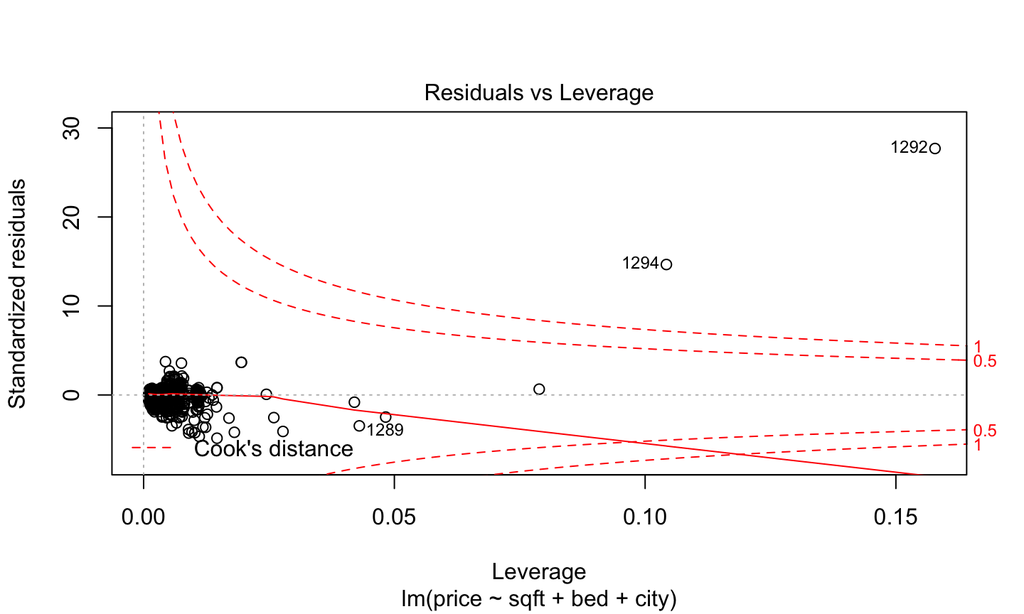

```r
plot(m1, 5)
```

## AVPs

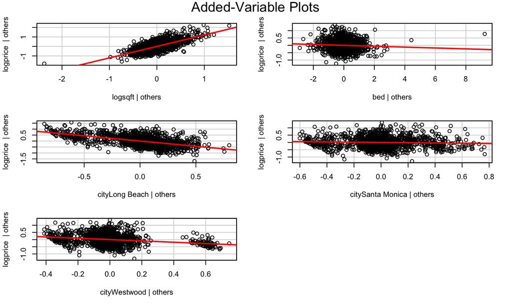

```r
LA <- transform(LA, logprice = log(price), logsqft = log(sqft))
m2 <- lm(logprice ~ logsqft + bed + city, data = LA)
library(car)
avPlots(m2)
```

## Diagnostics III

## Last time

We learned how structure in a residual plot can generally not be used to make specific inferences about where the model is misspecified. So we need other tools:

1. *Added Variable Plots*: demonstrate the relationship between a single predictor and the remaining variation in the data after a model has been fit.
2. *\(Y\) versus \(\hat{Y}\)*: used to assess whether the mean function is being well modeled
3. *Marginal model plots*: used to assess whether the mean function between each predictor and the response is being well modeled.

## Model 1

\[ \widehat{price} \sim sqft + bed + city \]

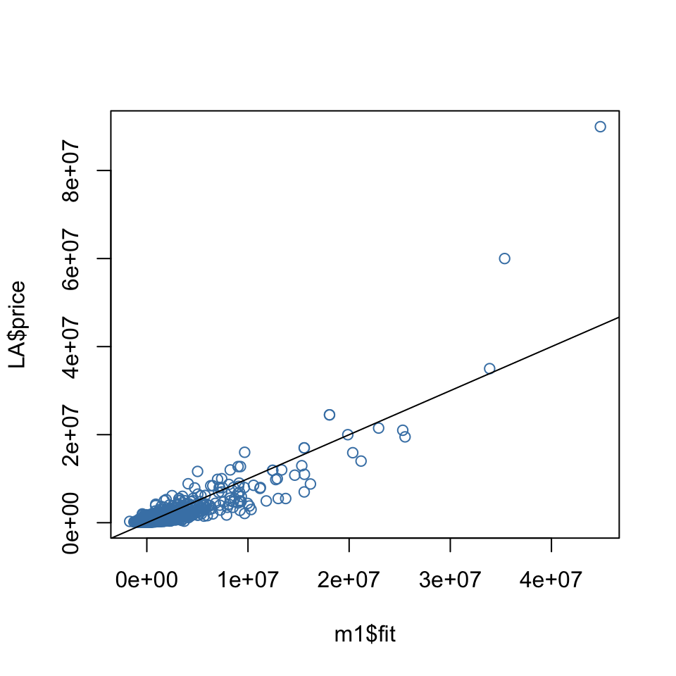

## Model 2

\[ \widehat{logprice} \sim logsqft + bed + city \]

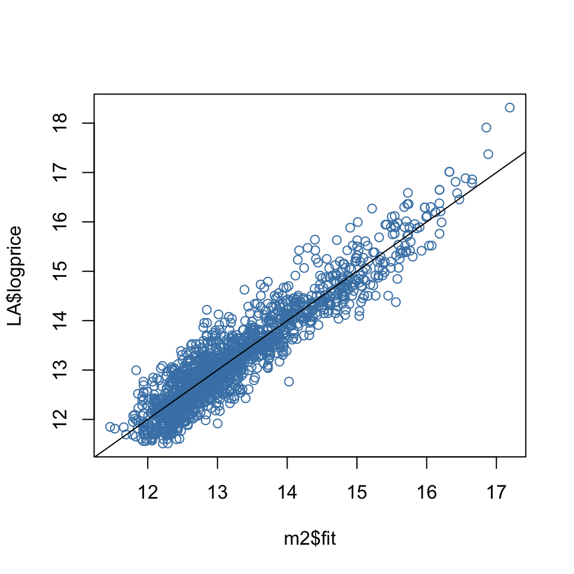

## \(Y\) versus \(\hat{Y}\)

Used to assess whether your model is doing a good job of modeling the response. If it is, you'll see points along the identity line. If it's not, there will be non-linear structure that you can assess on a predictor-by-predictor basis using marginal model plots.

## Marginal Model Plots

## Defective widgets

[figure not shown]

```r
defects <- read.table("http://www.stat.tamu.edu/~sheather/book/docs/datasets/defects.txt",
                      header = TRUE)
head(defects)
```

```
##   Case Temperature Density  Rate Defective
## 1    1        0.97   32.08 177.7       0.2
## 2    2        2.85   21.14 254.1      47.9
## 3    3        2.95   20.65 272.6      50.9
## 4    4        2.84   22.53 273.4      49.7
## 5    5        1.84   27.43 210.8      11.0
## 6    6        2.05   25.42 236.1      15.6
```

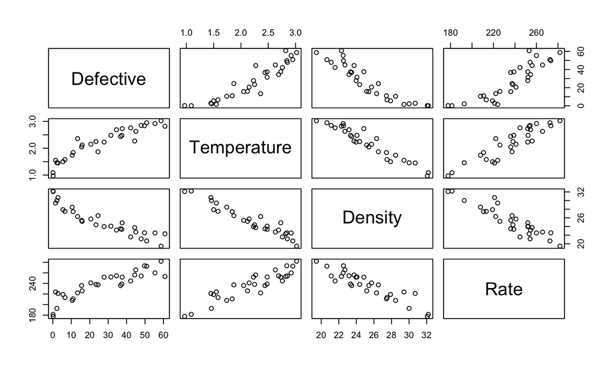

```r
pairs(Defective ~ Temperature + Density + Rate, data = defects)
```

## A first try

\[ \widehat{Defective} \sim Temperature + Density + Rate \]

```
##             Estimate Std. Error t value Pr(>|t|)
## (Intercept)  10.3244    65.9265  0.1566  0.87677
## Temperature  16.0779     8.2941  1.9385  0.06349
## Density      -1.8273     1.4971 -1.2206  0.23320
## Rate          0.1167     0.1306  0.8936  0.37972
```

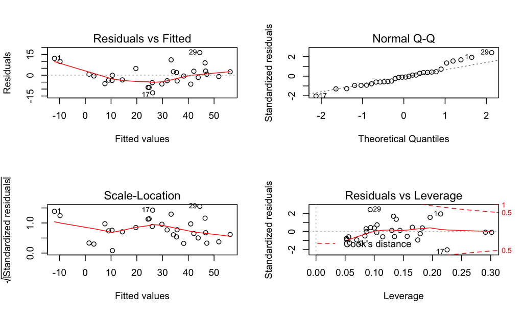

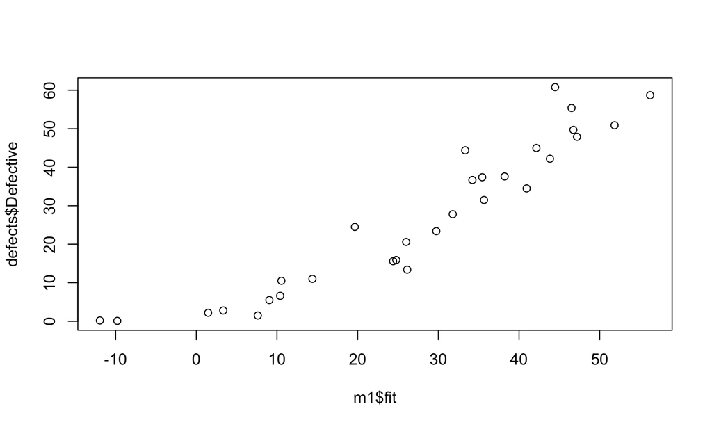

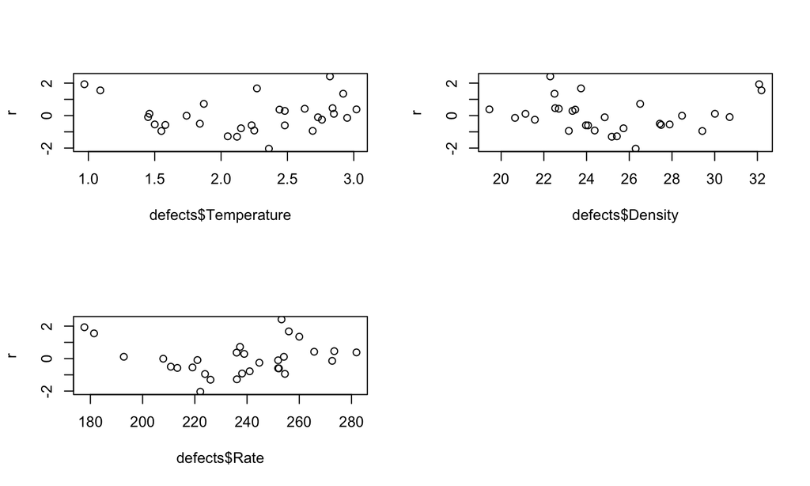

## Where to go from here?

The standardized residual plots and the plot of \(y\) on \(\hat{y}\) suggest that something is amiss, but what? We need to be sure that the structure in the *data* is being mirrored well by the structure in our *model*. This comparison is made for each predictor using the **marginal model plot**.

## Marginal relationships

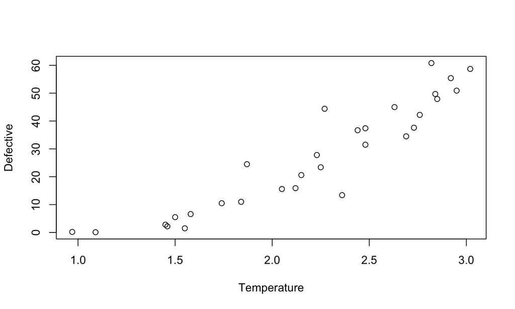

## Marginal relationships

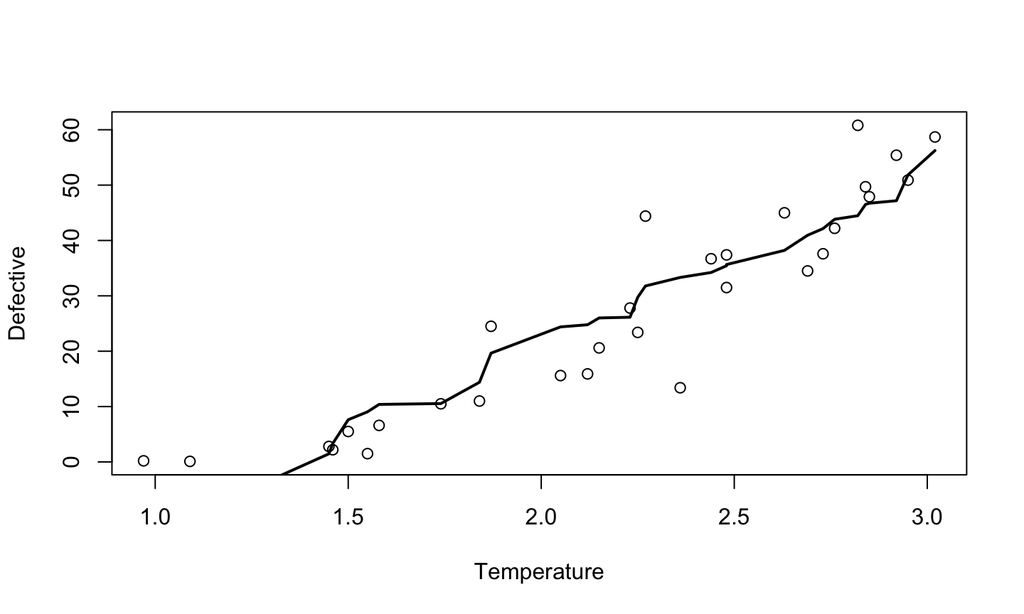

## Nonparametric methods

LOESS: locally-weighted scatterplot smoothing.

## Marginal relationships

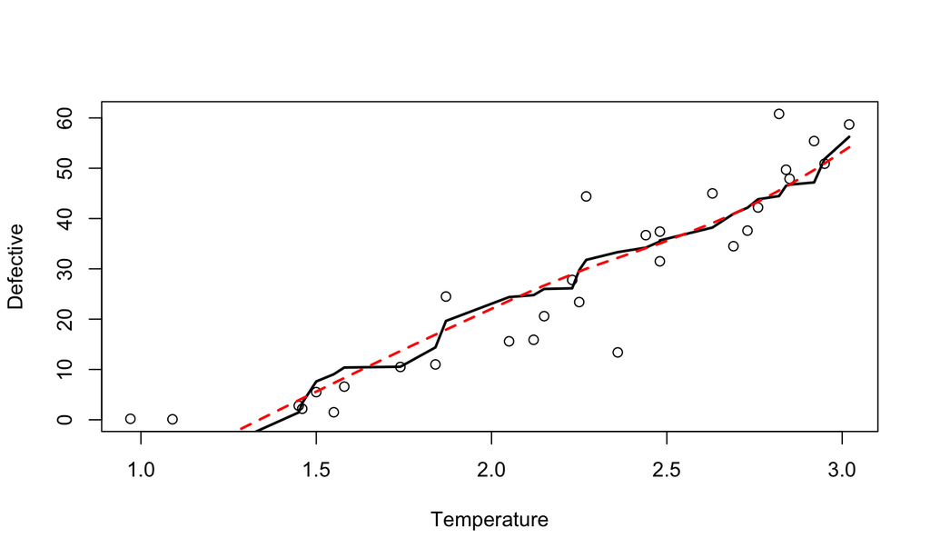

## Marginal relationships

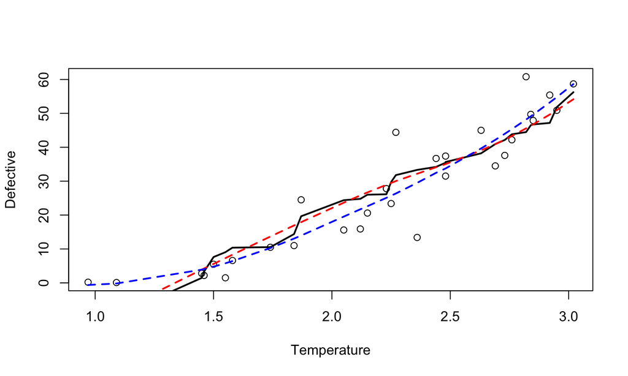

## Marginal model plot

Used to assess the marginal relationship between each predictor and the response. It compares the fit from the model with the nonparametric via to the scatterplot. If your model is well-specficied, these two lines will be close to coincident.

You can build them by hand using `loess()` or use `mmp()` in the `car` package.

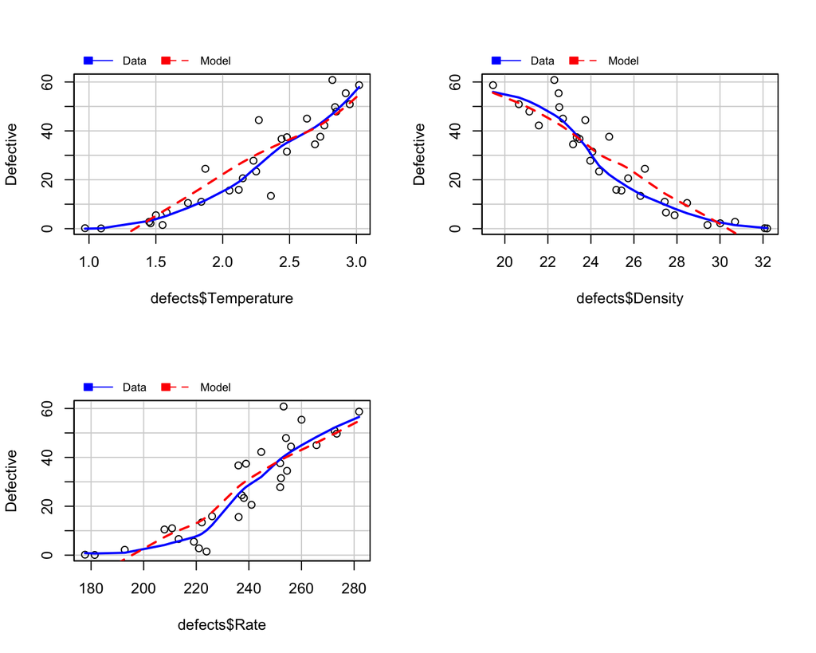

## An alternative model

\[ \widehat{\sqrt{Defective}} \sim Temperature + Density + Rate \]

```r
defects <- transform(defects, sqrtDefective = sqrt(Defective))
m2 <- lm(sqrtDefective ~ Temperature + Density + Rate, data = defects)
summary(m2)$coef
```

```
##             Estimate Std. Error t value Pr(>|t|)
## (Intercept)   5.5930    5.26401   1.062  0.29778
## Temperature   1.5652    0.66226   2.363  0.02587
## Density      -0.2917    0.11954  -2.440  0.02182
## Rate          0.0129    0.01043   1.237  0.22727
```

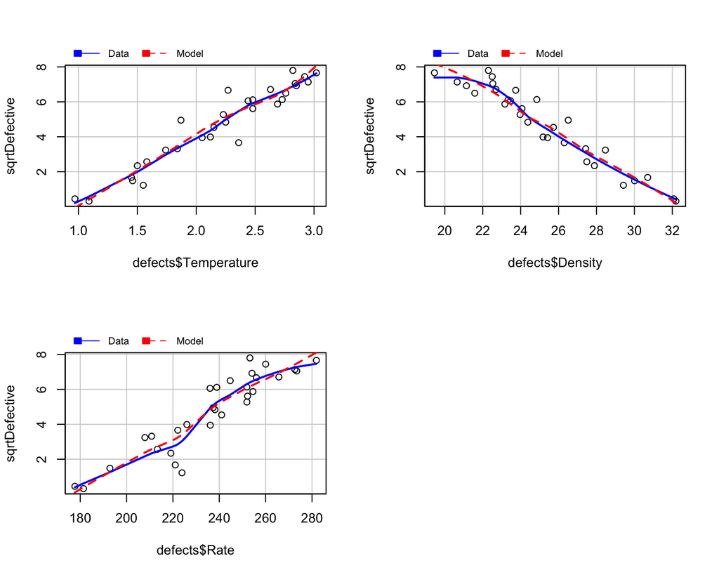

## Comparing m1 and m2

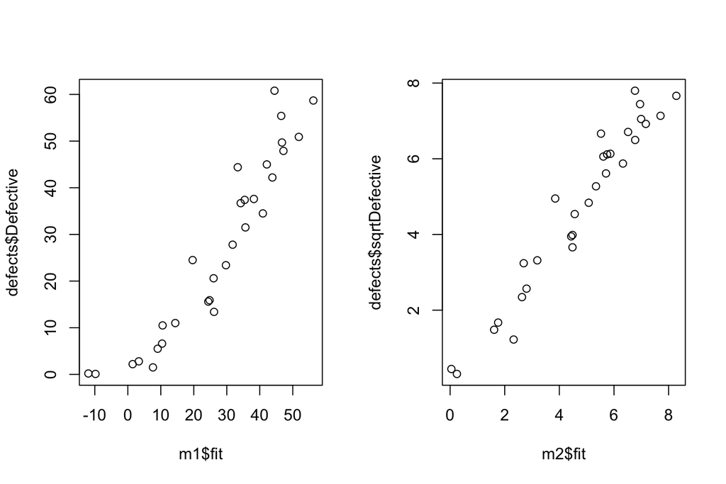

## AVP vs MMP

- **Marginal model plots**: are useful in checking to see that you're doing a good job of modeling the marginal relationship between a given predictor and the response.
- **Added variable plots**: assess how much variation in the response can be explained by a given predictor after the other predictors have already been taken into account (links to p-values).